# Lab 4

Kaz Sakamoto

4/1/2018

# K-means clustering

Let’s load some packages that we will be using

```r
library(GGally)
library(dplyr)
library(ggplot2)
```

we will load our data that we need which comes from the ACS. We have taken four demographic data points.

- Average Household Size
- Median Household Income
- Median Gross Rent
- Average Commute time in min

```r
readr::read_csv("../Data/ACS2016Counties.csv") %>%
    select(Geo_COUNTY, starts_with("SE")) %>%
    filter(complete.cases(.))-> counties

names(counties) <- c("countyID", "AvgHHSize",
                     "MedHHIncome", "MedGrossRent", "AvgCommute")
```

let’s first normalize our data so it’s easier to compare.

```r
df <- scale(counties[-1]) %>% as.data.frame()
```

Here is a calculation to create a chart of the total within-groups sums of squares against the number of clusters in a K-means solution. The output will start to look like a curve, and where the bend happens should be where we choose the number of K.

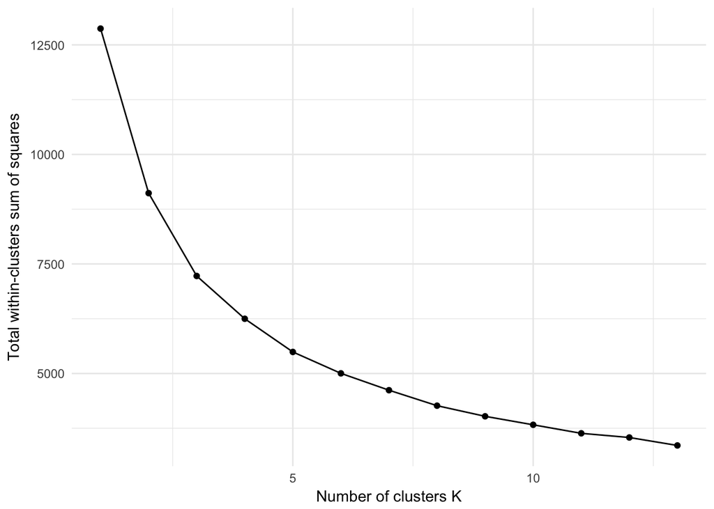

```r
kMax <- 13 # Maximal number of clusters
wss <- sapply(1:kMax,
        function(k){kmeans(df, k)$tot.withinss})

data.frame(wss, clusters = 1:kMax) %>%
    ggplot(aes(x = clusters, y = wss)) + geom_point() +
    geom_line() + xlab("Number of clusters K") +
       ylab("Total within-clusters sum of squares") + theme_minimal()
```

Here is another method to find the best K for clusters.

```r
library(NbClust)
set.seed(222)
nc <- NbClust(df %>% sample_frac(.35), min.nc=2, max.nc=10, method="kmeans")
```

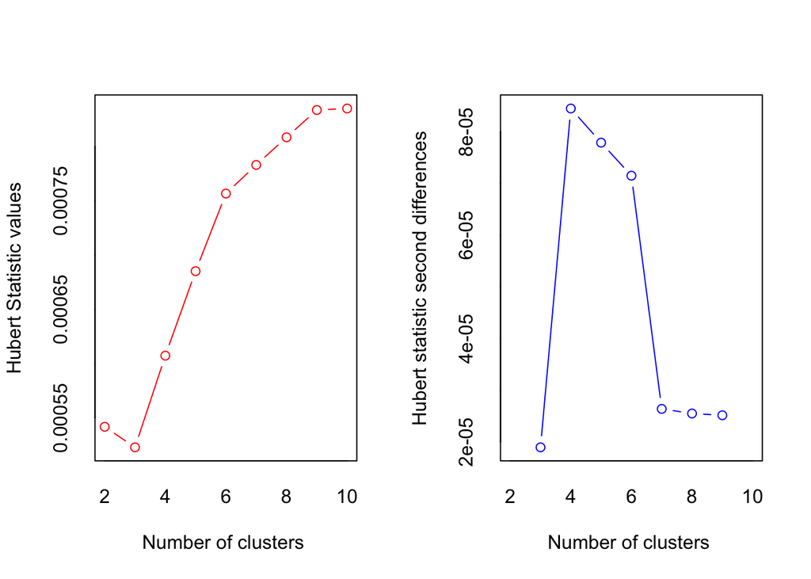

```
## *** : The Hubert index is a graphical method of determining the number of clusters.
##                 In the plot of Hubert index, we seek a significant knee that corresponds to a
##                 significant increase of the value of the measure i.e the significant peak in Hubert
##                 index second differences plot.
##
```

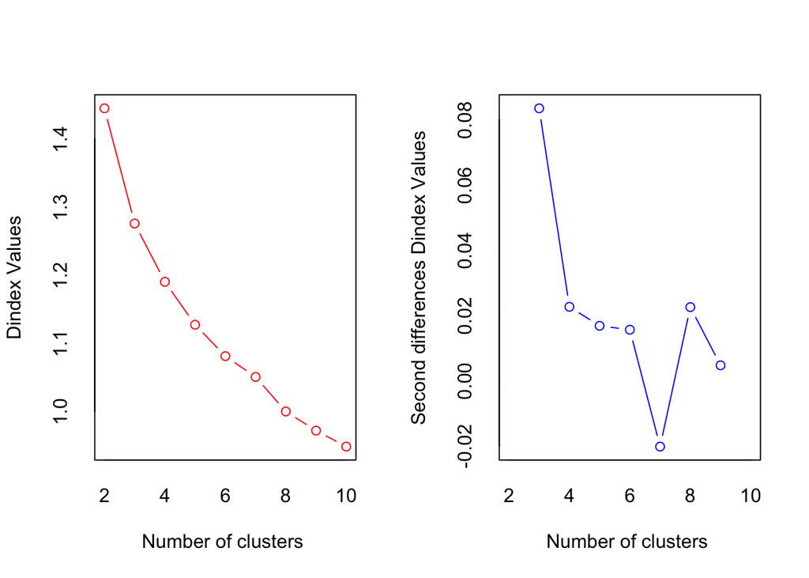

```
## *** : The D index is a graphical method of determining the number of clusters.
##                 In the plot of D index, we seek a significant knee (the significant peak in Dindex
##                 second differences plot) that corresponds to a significant increase of the value of
##                 the measure.
##
## * Among all indices:
## * 7 proposed 2 as the best number of clusters
## * 10 proposed 3 as the best number of clusters
## * 1 proposed 4 as the best number of clusters
## * 3 proposed 5 as the best number of clusters
## * 2 proposed 8 as the best number of clusters
## * 1 proposed 10 as the best number of clusters
##
##                    ***** Conclusion *****
##
## * According to the majority rule, the best number of clusters is  3
##
##
```

let’s check to see which k performed the best

```r
table(nc$Best.n[1,])
```

```
##
##  0  2  3  4  5  8 10
##  2  7 10  1  3  2  1
```

if we plot it out we can see that 2 and 3 are being recommended

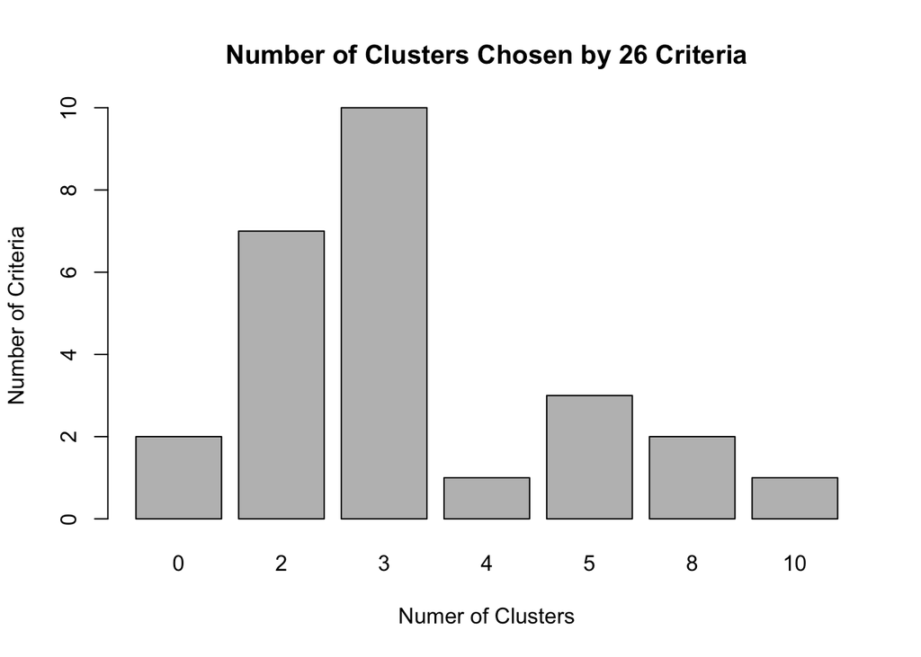

```r
barplot(table(nc$Best.n[1,]),
          xlab="Numer of Clusters", ylab="Number of Criteria",
          main="Number of Clusters Chosen by 26 Criteria")
```

running kmeans with 3 clusters

```r
kmeans(df, 3) -> k3
```

checking the size and centers of the clusters

```r
k3$size
```

```
## [1]  522 1650 1047
```

```r
k3$centers
```

```
##    AvgHHSize  MedHHIncome MedGrossRent AvgCommute
## 1  0.6582861  1.484148647    1.6804199  0.6973759
## 2 -0.4898260 -0.006212204   -0.1971729 -0.6147537
## 3  0.4437322 -0.730158030   -0.5270715  0.6211207
```

adding back labels to our dataset

```r
df$cluster <- as.factor(k3$cluster)
```

Let’s plot our results

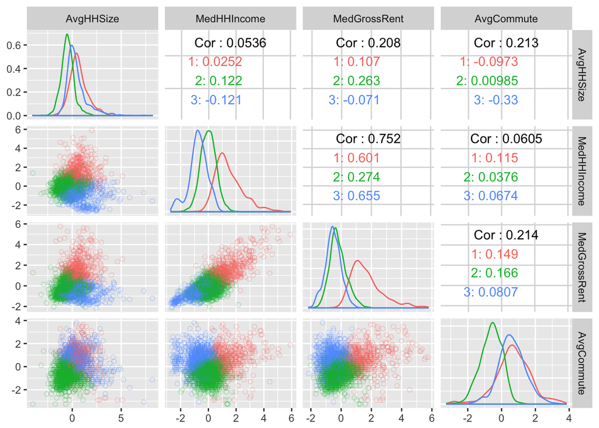

```r
ggally_mysmooth <- function(data, mapping, ...){
    ggplot(data = data, mapping=mapping) +
        geom_density(fill=NA)
}

ggpairs(df, 1:4, mapping = ggplot2::aes(color = cluster),
        lower = list(continuous = wrap("points", shape = 1, alpha = .25)),
        diag = list(continuous = ggally_mysmooth))
```

# K Nearest Neighbor

Let’s first read in the data

```r
MN <- readr::read_csv("../Data/PLUTO/MN_pluto.csv")
```

```r
MN %>% select(NumFloors, LotArea, AssessTot, LandUse, XCoord, YCoord) %>%
    filter(LandUse %in% c(5, 9) & complete.cases(.)) %>%
    mutate(LandUse = if_else(LandUse == 5, "Comm", "Park")) -> MN
```

Now let’s scale our variables

```r
MN %>% mutate(NumFloors = scale(NumFloors),
              LotArea = scale(LotArea),
              AssessTot = scale(AssessTot),
              LandUse = as.character(LandUse)) -> MN
```

```r
table(MN$LandUse)
```

```
##
## Comm Park
## 4530  348
```

```r
MN %>% group_by(LandUse) %>% sample_frac(size = 0.5) %>% ungroup() -> MNSamp
```

Let’s visualize what this looks like so far first with as AssessTot and NumFloors

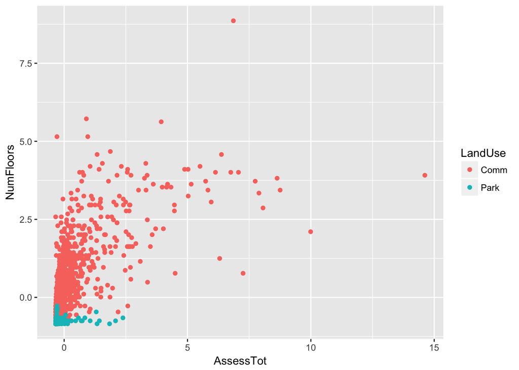

```r
ggplot(MNSamp, aes(x = AssessTot, y = NumFloors, color = LandUse)) + geom_point()
```

Let’s now take a look at plotting and XCoord and YCoord

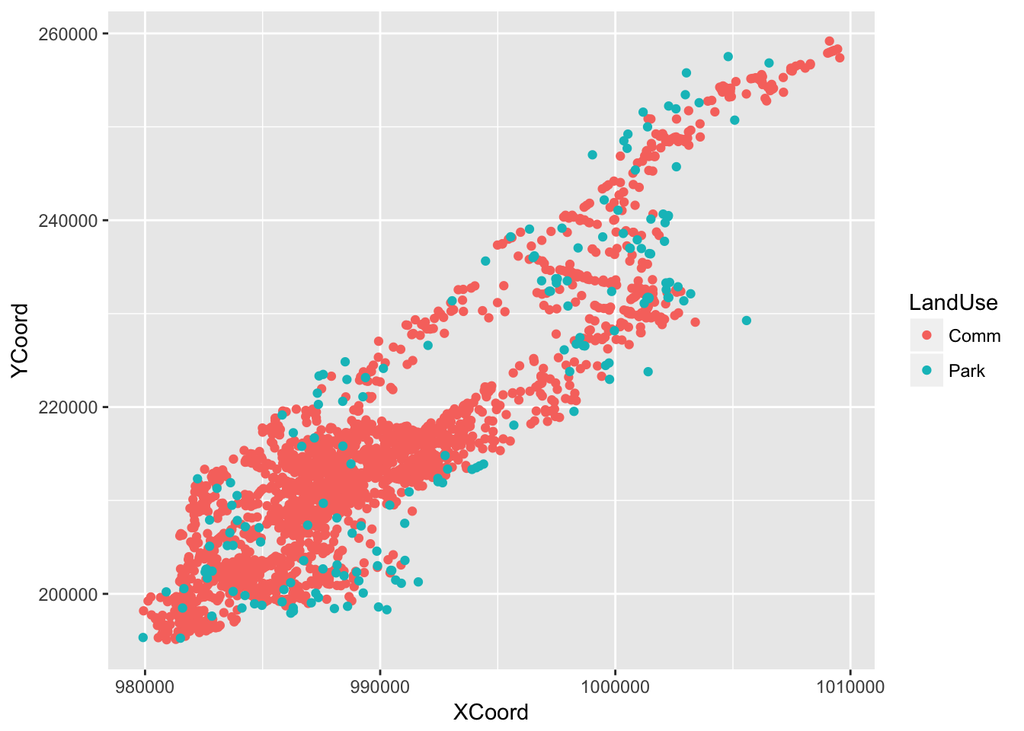

```r
ggplot(MNSamp, aes(x = XCoord, y = YCoord, color = LandUse)) + geom_point()
```

Now we are going to make the train test split of 70% train, 30% test.

```r
smp <- sample(2, nrow(MNSamp), replace=TRUE, prob=c(0.7, 0.3))
```

We will now take this sample vector and filter through our data

```r
trainDF <- MNSamp %>% filter(smp == 1) %>%
    select(AssessTot, NumFloors)
testDF <-  MNSamp %>% filter(smp == 2) %>%
    select(AssessTot, NumFloors)

trainLabel <- MNSamp %>% filter(smp == 1) %>%
    select(LandUse)
testLabel <- MNSamp %>% filter(smp == 2) %>%
    select(LandUse)
```

```r
library(class)
dfPred <- knn(trainDF, testDF, trainLabel$LandUse, k = 9)
```

```r
library(gmodels)
CrossTable(testLabel$LandUse,dfPred,prop.chisq = F)
```

```
##
##
##    Cell Contents
## |-------------------------|
## |                       N |
## |           N / Row Total |
## |           N / Col Total |
## |         N / Table Total |
## |-------------------------|
##
##
## Total Observations in Table:  745
##
##
##                   | dfPred
## testLabel$LandUse |      Comm |      Park | Row Total |
## ------------------|-----------|-----------|-----------|
##              Comm |       686 |         5 |       691 |
##                   |     0.993 |     0.007 |     0.928 |
##                   |     0.969 |     0.135 |           |
##                   |     0.921 |     0.007 |           |
## ------------------|-----------|-----------|-----------|
##              Park |        22 |        32 |        54 |
##                   |     0.407 |     0.593 |     0.072 |
##                   |     0.031 |     0.865 |           |
##                   |     0.030 |     0.043 |           |
## ------------------|-----------|-----------|-----------|
##      Column Total |       708 |        37 |       745 |
##                   |     0.950 |     0.050 |           |
## ------------------|-----------|-----------|-----------|
##
##
```

```r
testDF %>% bind_cols(testLabel) %>%
    mutate(pred = dfPred) %>%
    mutate(test = if_else(pred == LandUse, "Correct", "Wrong")) -> output
```

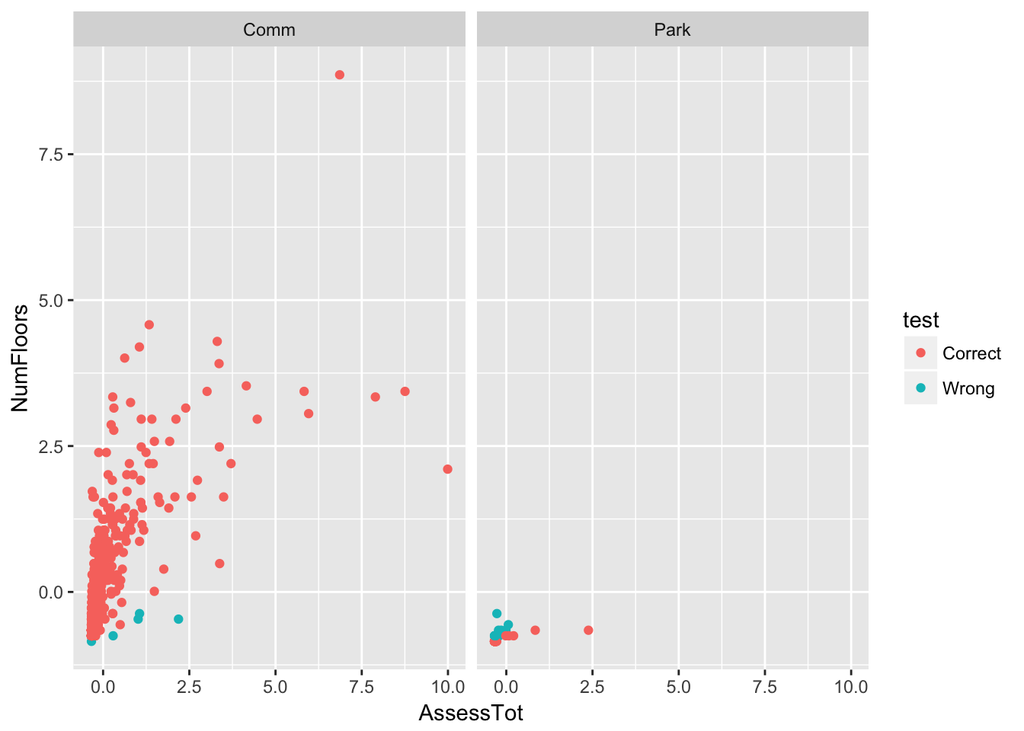

```r
ggplot(output, aes(x = AssessTot, y = NumFloors, color = test)) + geom_point() +
    facet_wrap( ~ LandUse)
```

Let’s try with x and y coordinates

```r
trainCoordDF <- MNSamp %>% filter(smp == 1) %>%
    select(XCoord, YCoord)
testCoordDF <-  MNSamp %>% filter(smp == 2) %>%
    select(XCoord, YCoord)

trainLabel <- MNSamp %>% filter(smp == 1) %>%
    select(LandUse)
testLabel <- MNSamp %>% filter(smp == 2) %>%
    select(LandUse)
```

```r
library(class)
dfCoordPred <- knn(trainCoordDF, testCoordDF, trainLabel$LandUse, k = 9)
```

```r
library(gmodels)
CrossTable(testLabel$LandUse,dfCoordPred,prop.chisq = F)
```

```
##
##
##    Cell Contents
## |-------------------------|
## |                       N |
## |           N / Row Total |
## |           N / Col Total |
## |         N / Table Total |
## |-------------------------|
##
##
## Total Observations in Table:  745
##
##
##                   | dfCoordPred
## testLabel$LandUse |      Comm |      Park | Row Total |
## ------------------|-----------|-----------|-----------|
##              Comm |       681 |        10 |       691 |
##                   |     0.986 |     0.014 |     0.928 |
##                   |     0.930 |     0.769 |           |
##                   |     0.914 |     0.013 |           |
## ------------------|-----------|-----------|-----------|
##              Park |        51 |         3 |        54 |
##                   |     0.944 |     0.056 |     0.072 |
##                   |     0.070 |     0.231 |           |
##                   |     0.068 |     0.004 |           |
## ------------------|-----------|-----------|-----------|
##      Column Total |       732 |        13 |       745 |
##                   |     0.983 |     0.017 |           |
## ------------------|-----------|-----------|-----------|
##
##
```

```r
testCoordDF %>% bind_cols(testLabel) %>%
    mutate(pred = dfCoordPred) %>%
    mutate(test = if_else(pred == LandUse, "Correct", "Wrong")) -> output
```

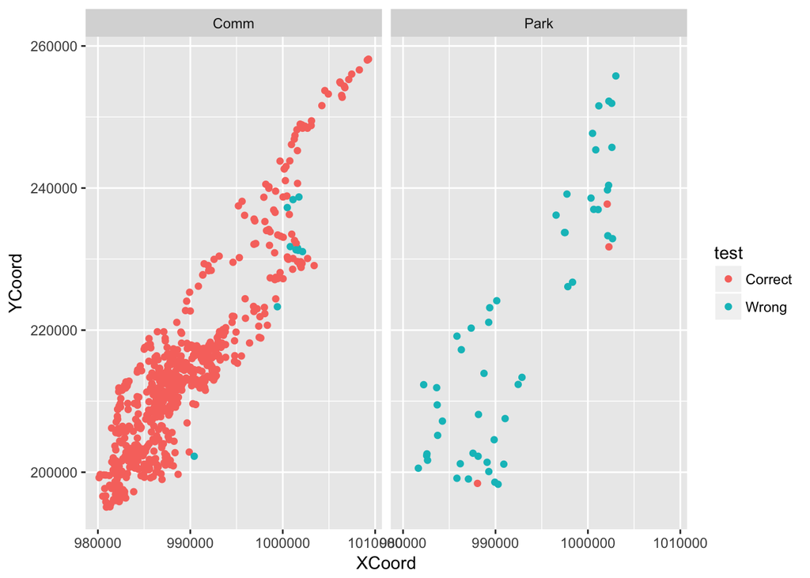

```r
ggplot(output, aes(x = XCoord, y = YCoord, color = test)) + geom_point() +
    facet_wrap( ~ LandUse)
```